# Proyecto Final

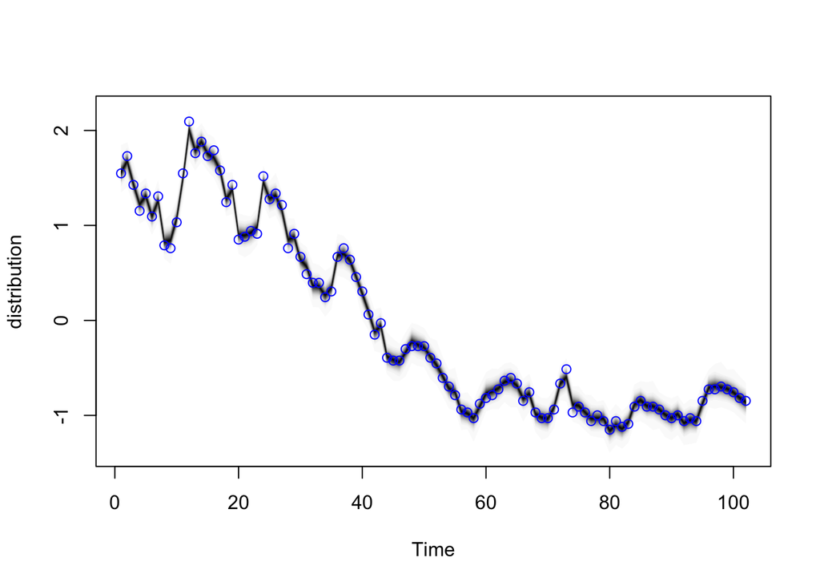

```r
plot(model2)
```

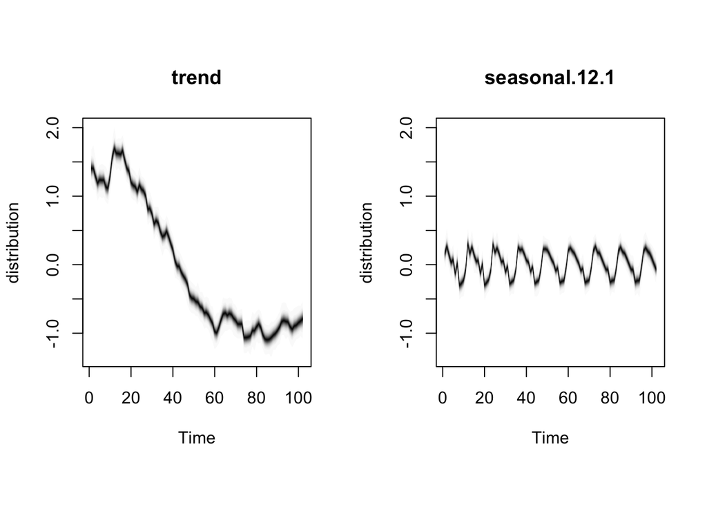

```r
plot(model2, "components")
```

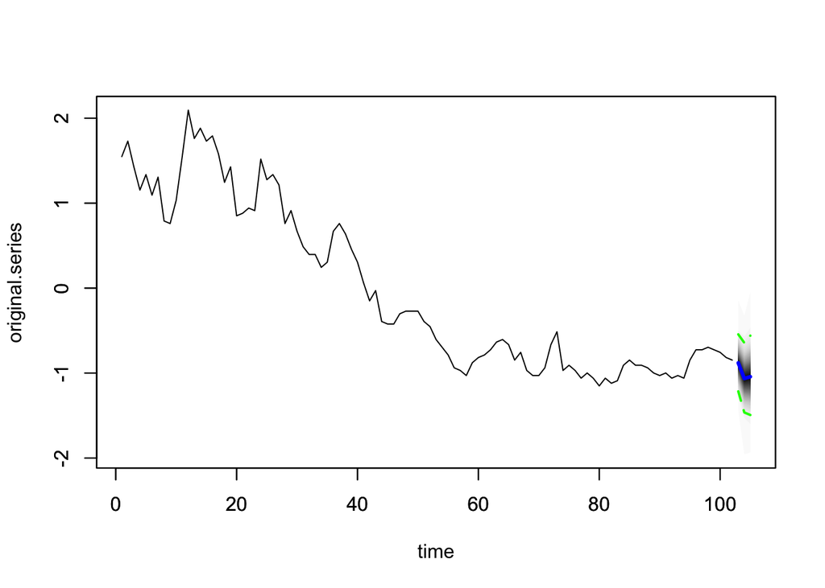

```r
pred2 <- predict(model2, horizon = 3)
plot(pred2, plot.original = 102)
```

Un tercer modelo contempla un componente de autocorelación 2 basado en las gráficas de autocorrelación y autocorrelación parcial previamente modstradas.

```r
ss3 <- AddAr(ss2, data_housing$HSN1FNSA, lags = 2)
model3 <- bsts(data_housing$HSN1FNSA,
               state.specification = ss3,
               niter = 2000)
```

```
## =-=-=-=-= Iteration 0 Tue May 16 22:03:41 2023 =-=-=-=-=
## =-=-=-=-= Iteration 200 Tue May 16 22:03:42 2023 =-=-=-=-=
## =-=-=-=-= Iteration 400 Tue May 16 22:03:42 2023 =-=-=-=-=
## =-=-=-=-= Iteration 600 Tue May 16 22:03:43 2023 =-=-=-=-=
## =-=-=-=-= Iteration 800 Tue May 16 22:03:44 2023 =-=-=-=-=
## =-=-=-=-= Iteration 1000 Tue May 16 22:03:45 2023 =-=-=-=-=
## =-=-=-=-= Iteration 1200 Tue May 16 22:03:45 2023 =-=-=-=-=
## =-=-=-=-= Iteration 1400 Tue May 16 22:03:46 2023 =-=-=-=-=
## =-=-=-=-= Iteration 1600 Tue May 16 22:03:47 2023 =-=-=-=-=
## =-=-=-=-= Iteration 1800 Tue May 16 22:03:48 2023 =-=-=-=-=
```

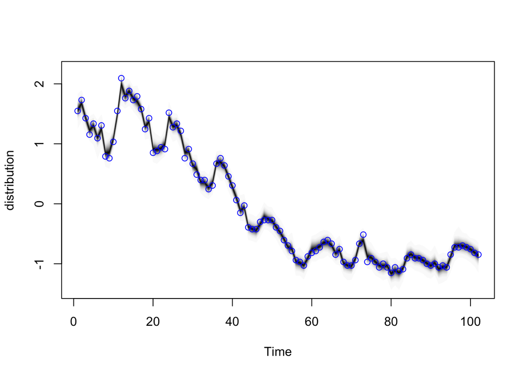

```r
plot(model3)
```

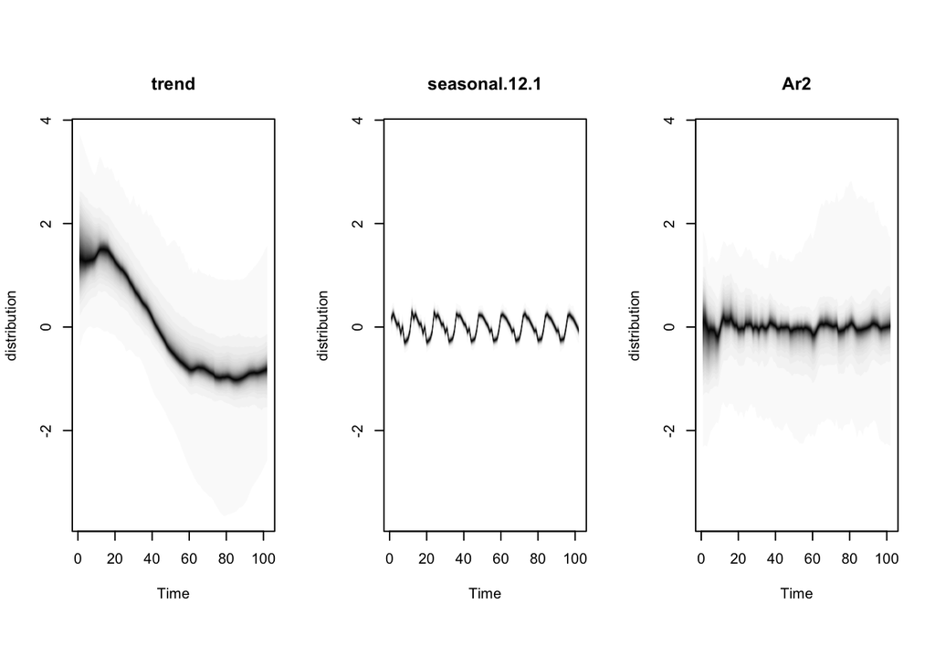

```r
plot(model3, "components")
```

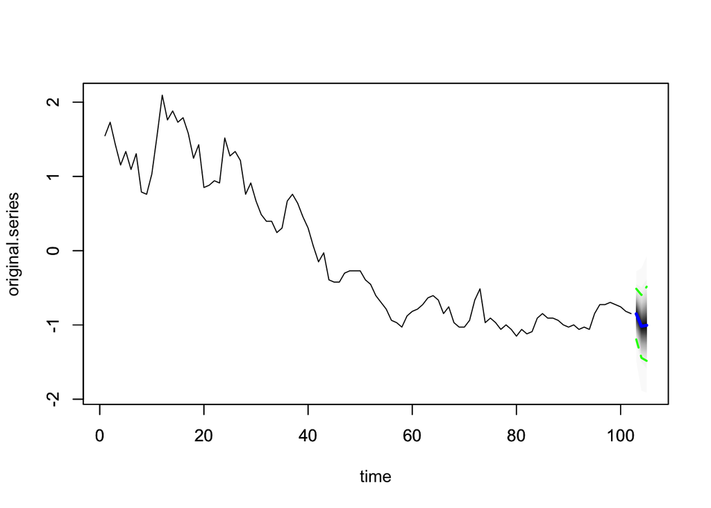

```r
pred2 <- predict(model3, horizon = 3)
plot(pred2, plot.original = 102)
```

Para definir si las variables obtenidas con las búsquedas de Google son útiles en la predicción inmediata que buscamos se realizó un un último modelo que considera el componente de regresión con 69 coeficientes para las covariables que queremos usar como regresoras.

```r
#por default busca sólo tomar una variable
model4 <- bsts( HSN1FNSA~ .,
               state.specification = ss3,
               niter = 2000,
               data = select(data_housing, -1),
               expected.model.size = 5)
```

```
## =-=-=-=-= Iteration 0 Tue May 16 22:03:50 2023 =-=-=-=-=
## =-=-=-=-= Iteration 200 Tue May 16 22:03:51 2023 =-=-=-=-=
## =-=-=-=-= Iteration 400 Tue May 16 22:03:52 2023 =-=-=-=-=
## =-=-=-=-= Iteration 600 Tue May 16 22:03:53 2023 =-=-=-=-=
## =-=-=-=-= Iteration 800 Tue May 16 22:03:54 2023 =-=-=-=-=
## =-=-=-=-= Iteration 1000 Tue May 16 22:03:54 2023 =-=-=-=-=
## =-=-=-=-= Iteration 1200 Tue May 16 22:03:55 2023 =-=-=-=-=
## =-=-=-=-= Iteration 1400 Tue May 16 22:03:56 2023 =-=-=-=-=
## =-=-=-=-= Iteration 1600 Tue May 16 22:03:57 2023 =-=-=-=-=
## =-=-=-=-= Iteration 1800 Tue May 16 22:03:58 2023 =-=-=-=-=
```

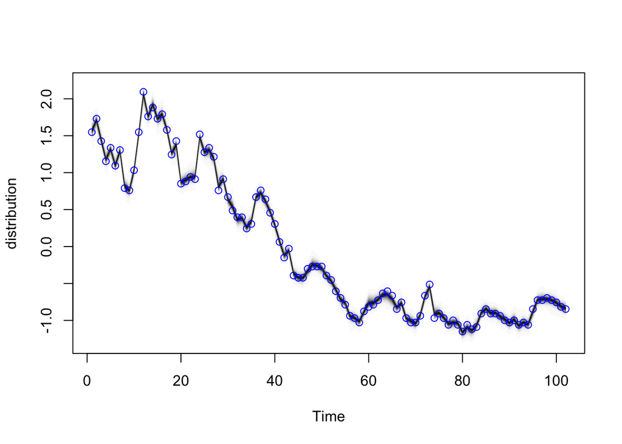

```r
plot(model4)
```